# data608projectproposal

jim lung

March 24, 2018

# Data 608 Project Proposal

## Aim:

** Use of visualization to conduct visual analytics on data analysis Provide answer and question to get the result of analysis Provide user-friendly interface to explore the data as well as find insights from it **

## Methodology:

** Use shiny app provides efficient ways to manipulate and visualize data To explore salary data of 8 professions based on the data about prevailing wage of foreign employers in the United States. The 8 professions include: Data scientist, Software engineers, Data Analyst, Business Analyst, Management Consultant, Assistant Professor, Attorney, Teacher **

## Data source:

** The dataset is from the United States Department of Labor, Employment & Training Administration **https://www.foreignlaborcert.doleta.gov/performancedata.cfm** The filtered data for this application contains total 167,278 cases (in 17 columns) in 2015 It is about the prevailing wage data of foreign employers seeking to file applications in the Permanent Labor Certification Program prevailing wage data of US natives are not included **

### Data Glimpse - to deal with NA/missing value

```r
library(knitr)
library(dplyr)
library(ggplot2)
library(plotly)
library(sqldf)
library(googleVis)

#x <- read.csv("salary.csv", header = TRUE, sep = ",", stringsAsFactors = FALSE)
load("salary.Rdata")
head(df)
```

```
##    JOB_TITLE_SUBGROUP                           JOB_TITLE
## 1   software engineer                   SOFTWARE ENGINEER
## 2 assistant professor    Assistant Professor of Marketing
## 3             teacher           SPECIAL EDUCATION TEACHER
## 4             teacher                     SCIENCE TEACHER
## 5   software engineer            SENIOR SOFTWARE ENGINEER
## 6    business analyst ORACLE SCM ANALYST/BUSINESS ANALYST
##                            PREVAILING_WAGE_SOC_TITLE
## 1                  Software Developers, Applications
## 2                   Business Teachers, Postsecondary
## 3 Special Education Teachers, Kindergarten and Eleme
## 4         Biological Science Teachers, Postsecondary
## 5              Software Developers, Systems Software
## 6                          Computer Systems Analysts
##                                        EMPLOYER_NAME PAID_WAGE_PER_YEAR
```

[output cut: 41 more lines]

### Cleaning, calculating and re-arrange between job, wage and location

```r
arr <- df[,c(8,5)]
colnames(arr) <- c("region", "WAGE")
arr <- aggregate(arr[, 2], list(arr$region), mean)
colnames(arr) <- c("region", "WAGE")
arr$WAGE<-round(arr$WAGE)

salarylevel <- arr %>% arrange(desc(WAGE))
salarylevel
```

```
##                      region   WAGE
## 1             West Virginia 109427
## 2                California 103571
## 3                Washington 102177
## 4                  New York  91602
## 5                  Arkansas  90271
## 6                   Alabama  87326
## 7             Massachusetts  86611
## 8              Pennsylvania  83889
## 9      District of Columbia  81968
## 10              Mississippi  81951
## 11                   Oregon  81531
## 12                   Kansas  81032
## 13                 Kentucky  80147
## 14              Connecticut  79579
```

[output cut: 43 more lines]

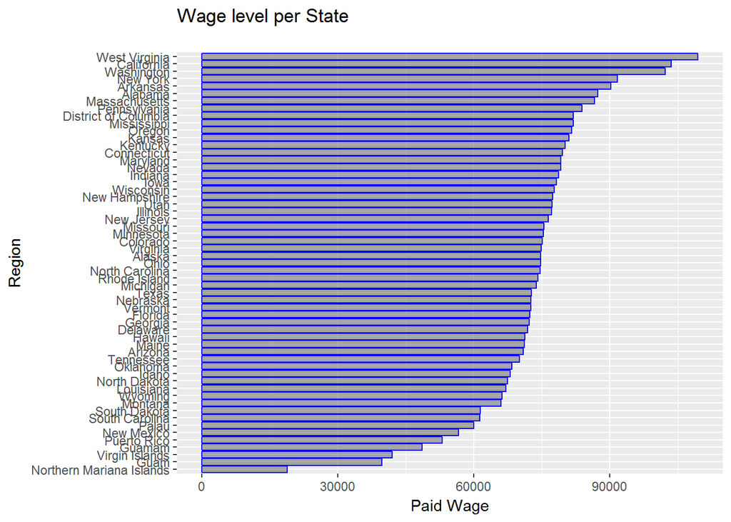

```r
ordered_states <- rev(salarylevel$region)
salarylevel$region <- factor(salarylevel$region, levels = ordered_states)

ggplot(salarylevel, aes(x = region, y = WAGE)) + geom_bar(stat = "identity", alpha = 0.5, col = "blue") + coord_flip() + ggtitle("Wage level per State\n") + scale_y_continuous("Paid Wage") + scale_x_discrete("Region")
```

## We will use the shiny function to compare the wage, job nature and location.

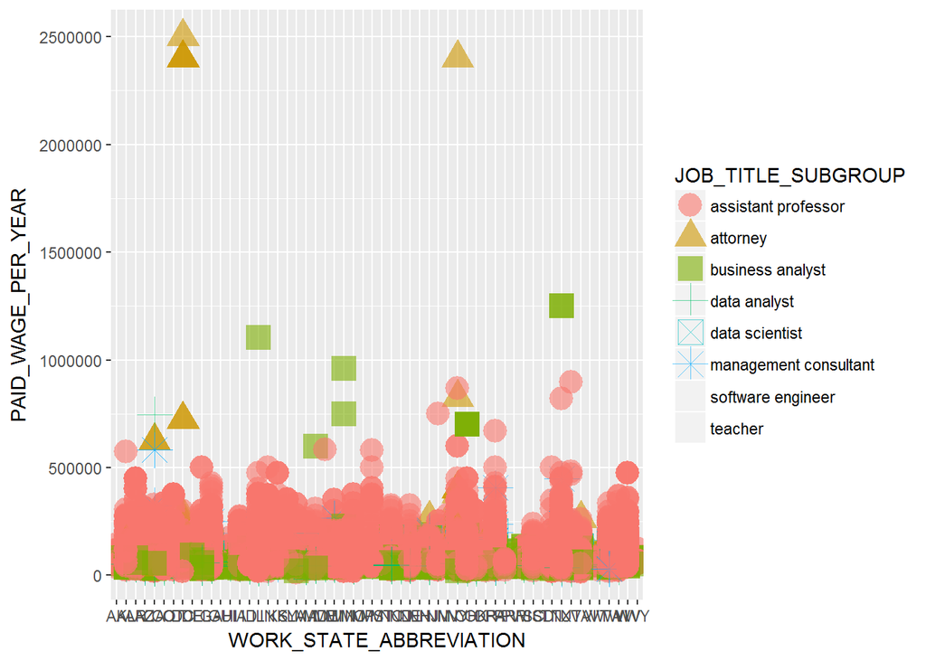

```r
ggplot(df, aes(x=WORK_STATE_ABBREVIATION, y=PAID_WAGE_PER_YEAR, color=JOB_TITLE_SUBGROUP, shape=JOB_TITLE_SUBGROUP)) + geom_point(size=6, alpha=0.6)
```

#### Tools To Be Used:

**GoogleVis** **Plotly** **GGplot2** **Sqldf**

#### Packages To Be Used:

**Plotly** **Knitr** **Dplyr** **Plyr** **MASS** **Reshape2** **Ggplot2** **Graphics** **Ggthemes** **GoogleVis** **etc**